This will guide you through the steps required to complete Peer Assignment 1.

First, you will need to install the “date” and “plyr” packages, if not already installed.

install.packages(“date”)

install.packages(“plyr”)

Then create a temporary folder, download the data from the course website, and read the unzipped file into a data frame “activity”.

```r
temp <- tempfile()
download.file("https://d396qusza40orc.cloudfront.net/repdata%2Fdata%2Factivity.zip", temp, method="curl")
activity <- read.csv(unz(temp, "activity.csv"))
unlink(temp)
```

Format the “date” variable as a date.

```r
library(date)
activity$date<-as.Date(activity$date, "%Y-%m-%d")
```

Plot a histogram of steps taken daily.

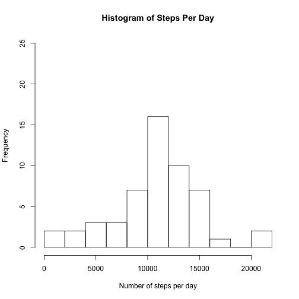

```r
hist(tapply(activity$steps, activity$date, sum), main="Histogram of Steps Per Day", xlab="Number of steps per day", ylab="Frequency", ylim=c(0,25), breaks=10)
```

Then calculate the mean steps per day.

```r
mean(tapply(activity$steps, activity$date, sum), na.rm=TRUE)
```

```
## [1] 10766.19
```

And then the median steps per day.

```r
median(tapply(activity$steps, activity$date, sum), na.rm=TRUE)
```

```
## [1] 10765
```

Plot the daily activity pattern, averaged over all days.

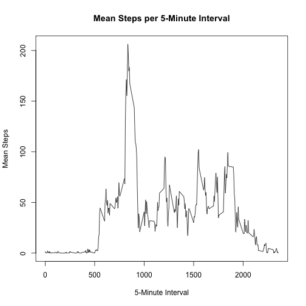

```r
plot(as.numeric(levels(as.factor(activity$interval))), tapply(activity$steps, activity$interval, mean, na.rm=TRUE), type="l", main="Mean Steps per 5-Minute Interval", xlab="5-Minute Interval", ylab="Mean Steps")
```

Then identify the 5-minute interval with the highest mean number of steps over all days.

```r
activity$interval[which.max(tapply(activity$steps, activity$interval, mean, na.rm=TRUE))]
```

```
## [1] 835
```

Next, we'll impute missing values. First, count the intervals with missing steps.

```r
sum(is.na(activity$steps))
```

```
## [1] 2304
```

Impute the missing values with the median value of steps for that interval across all days.

```r
library(plyr)
activityimp <- ddply(activity, .(interval), transform, steps=ifelse(is.na(steps), median(steps, na.rm=TRUE), steps))
```

Plot a histogram of daily steps with the new imputed values.

[figure not shown]

```r
hist(tapply(activityimp$steps, activity$date, sum), main="Histogram of Steps Per Day", xlab="Number of steps per day", ylab="Frequency", ylim=c(0,25), breaks=10)
```

Calculate the mean steps per day with new imputed values.

```r
mean(tapply(activityimp$steps, activityimp$date, sum), na.rm=TRUE)
```

```
## [1] 9503.869
```

And then calculate the median steps per day with new imputed values.

```r
median(tapply(activityimp$steps, activityimp$date, sum), na.rm=TRUE)
```

```
## [1] 10395
```

Note that the new values (mean 9503 and median 10395) are lower than those from the non-imputed data (mean 10766 and median 10765).

Next, we'll examine the data by weekdays and weekend days. First, classify the dates as weekdays or weekend days and subset the data into two data sets.

```r
activityimp$weekend <- ifelse(weekdays(activityimp$date)=="Saturday"|weekdays(activityimp$date)=="Sunday", TRUE, FALSE)
activityweek<-activityimp[activityimp$weekend=="FALSE",]
activityweekend<-activityimp[activityimp$weekend=="TRUE",]
```

Plot the average daily activity patterns for weekdays and weekend days separately.

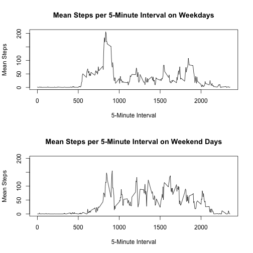

```r
par(mfrow=c(2,1))
## Weekday plot
plot(as.numeric(levels(as.factor(activityweek$interval))), tapply(activityweek$steps, activityweek$interval, mean, na.rm=TRUE), type="l", main="Mean Steps per 5-Minute Interval on Weekdays", xlab="5-Minute Interval", ylab="Mean Steps")
## Weekend plot
plot(as.numeric(levels(as.factor(activityweekend$interval))), tapply(activityweekend$steps, activityweekend$interval, mean, na.rm=TRUE), type="l", main="Mean Steps per 5-Minute Interval on Weekend Days", xlab="5-Minute Interval", ylab="Mean Steps", ylim=c(0,200))
```